# Data Structure:

Data structure is a data organization, management, and storage format that enables efficient access and modification. More precisely, a data structure is a collection of data values, the relationships among them, and the functions or operations that can be applied to the data.

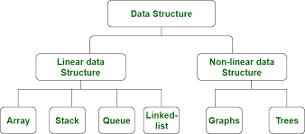

## 1. Linear Data Structure:

Linear data structure used to store homogeneous / Non homogeneous elements at contiguous locations.

**For example:** let us say, we want to store marks of all students in a class, we can use an list to store them. This helps in reducing the use of number of variables as we don’t need to create a separate variable for marks of every students. All marks can be accessed by simply traversing the list

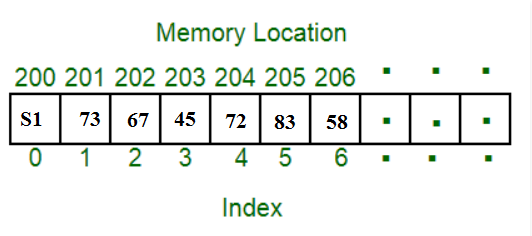

## a) List Array

An list array is a collection of items stored at contiguous memory locations. The idea is to store multiple items of the same type together. This makes it easier to calculate the position of each element by simply adding an offset to a base value, i.e., the memory location of the first element of the list array (generally denoted by the name of the list array).

**Syntax:** array(data type, value list)

```python
import array as arr
a=arr.array("i",[2,3,4,5])
print(type(a))
print(a)
```

```
<class 'array.array'>
array('i', [2, 3, 4, 5])
```

```python
import array as arr
a=arr.array("i",[2,3,4,5])
for i in range (0,4):
    print(a[i])
```

```
2
3
4
5
```

**Operations on Array :**

i) **append()**:- This function is used to add the value mentioned in its arguments at the end of the array.

```python
import array as arr
a=arr.array("i",[1,2,3,4,5])
a.append(6)
print(a)
```

```
array('i', [1, 2, 3, 4, 5, 6])
```

ii) **insert(i,x)** :- This function is used to add the value(x) at the ith position specified in its argument.

```python
import array as arr
a=arr.array("i",[1,2,3,4,5])
a.insert(1,5)
print(a)
```

```
array('i', [1, 5, 2, 3, 4, 5])
```

iii) **pop()**:- This function removes the element at the position mentioned in its argument and returns it.

```python
import array as arr
a=arr.array("i",[1,2,3,4,5])
a.pop(3)
print(a)
```

```
array('i', [1, 2, 3, 5])
```

iv) **remove()**:- This function is used to remove the first occurrence of the value mentioned in its arguments.

```python
import array as arr
a=arr.array("i",[1,2,3,4,5])
a.remove(3)
print(a)
```

```
array('i', [1, 2, 4, 5])
```

**Time Complexity**

Let size of list array be n.

**Accessing Time: O(1)** [This is possible because elements are stored at contiguous locations]

**Search Time: O(n)** for Sequential Search: **O(log n)** for Binary Search [If Array is sorted]

**Insertion Time: O(n)** [The worst case occurs when insertion happens at the Beginning of an array and requires shifting all of the elements]

**Deletion Time: O(n)** [The worst case occurs when deletion happens at the Beginning of an array and requires shifting all of the elements]

## b) Linked list

A linked list is a linear data structure (like List arrays) where each element is a separate object. Each element (that is node) of a list is comprising of two items – the data and a reference to the next node.

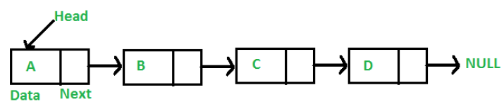

**Advantages over arrays**

Ease of insertion/deletion

**Drawbacks:**

1) Random access is not allowed.

2) Extra memory space for a pointer is required with each element of the list.

3) Not cache friendly.

**Representation:**

```python
# Node class
class Node:

    # Function to initialize the node object
    def __init__(self, data):
        self.data = data  # Assign data
        self.next = None  # Initialize next as null

# Linked List class
class LinkedList:

    # Function to initialize the Linked List object
    def __init__(self):
        self.head = None

# lets create linked list with head alonge with three nodes
llist = LinkedList()
first= Node(1)
second = Node(2)
third = Node(3)
llist.head=first
first.next=second
second.next=third

'''
     So all three nodes are linked.

    llist.head        second              third
         |                |                  |
         |                |                  |
    +----+------+     +----+------+     +----+------+
    | 1  |  o-------->| 2  |  o-------->|  3 | null |
    +----+------+     +----+------+     +----+------+
    '''
```

**Operations on linkedlist :**

i) **Linked List Traversal**

```python
class Node: # used for creating node in linkedlist
    def __init__(self,data):
        self.data=data
        self.next=None
class Linkedlist: # used for linking all node and carrying head pointer(head)
    def __init__(self):
        self.head=None
    def viewnode(self):# it is used for print linkedlist all elements
        temp=self.head
        while temp!=None:
            print(temp.data,end=(" "))
            temp=temp.next
llist = Linkedlist()
first= Node(1)
second = Node(2)
third = Node(3)
llist.head=first
first.next=second
second.next=third
llist.viewnode()
```

```
1 2 3
```

ii) **Delete first node**

```python
class Node: # used for creating node in linkedlist
    def __init__(self,data):
        self.data=data
        self.next=None
class Linkedlist: # used for linking all node and carrying head pointer(head)
    def __init__(self):
        self.head=None

    def deletefirst(self): #it is used for deleting first node
        if self.head==None:
            print("linked list empty")
        else:
            self.head=self.head.next

    def viewnode(self):# it is used for print linkedlist all elements
        temp=self.head
        while temp!=None:
            print(temp.data,end=(" "))
            temp=temp.next

llist = Linkedlist()
first= Node(1)
second = Node(2)
third = Node(3)
llist.head=first
first.next=second
second.next=third
llist.viewnode()
llist.deletefirst()
print()
llist.viewnode()
```

```
1 2 3
2 3
```

iii) **delete last node**

```python
class Node: # used for creating node in linkedlist
    def __init__(self,data):
        self.data=data
        self.next=None
class Linkedlist: # used for linking all node and carrying head pointer(head)
    def __init__(self):
        self.head=None

    def deletelast(self): #it is used for deleting last node
          temp=self.head
          while (temp.next.next)!= None:
              temp=temp.next
          temp.next=None

    def viewnode(self):# it is used for print linkedlist all elements
        temp=self.head
        while temp!=None:
            print(temp.data,end=(" "))
            temp=temp.next

llist = Linkedlist()
first= Node(1)
second = Node(2)
third = Node(3)
llist.head=first
first.next=second
second.next=third
llist.viewnode()
llist.deletelast()
print()
llist.viewnode()
```

```
1 2 3
1 2
```

iv) **delete any node**

```python
class Node: # used for creating node in linkedlist
    def __init__(self,data):
        self.data=data
        self.next=None
class Linkedlist: # used for linking all node and carrying head pointer(head)
    def __init__(self):
        self.head=None

    def deleteany(self,node): #it is used for deleting any node
          temp=self.head
          for i in range(2, node):
              temp=temp.next
          temp.next=temp.next.next

    def viewnode(self):# it is used for print linkedlist all elements
        temp=self.head
        while temp!=None:
            print(temp.data,end=(" "))
            temp=temp.next

llist = Linkedlist()
first= Node(1)
second = Node(2)
third = Node(3)
fourth=Node(4)
fifth=Node(5)
llist.head=first
first.next=second
second.next=third
third.next=fourth
fourth.next=fifth
llist.viewnode()
llist.deleteany(2)
print()
llist.viewnode()
```

```
1 2 3 4 5
1 3 4 5
```

v) **insert node at last**

```python
class Node: # used for creating node in linkedlist
    def __init__(self,data):
        self.data=data
        self.next=None
class Linkedlist: # used for linking all node and carrying head pointer(head)
    def __init__(self):
        self.head=None

    def insertlast(self,value): #it is used for creating new node and adding at last
        newnode=Node(value)
        if self.head==None:
            self.head=newnode
        else:
            temp=self.head
            while temp.next!=None:
                temp=temp.next
            temp.next=newnode

    def viewnode(self):# it is used for print linkedlist all elements
        temp=self.head
        while temp!=None:
            print(temp.data,end=(" "))
            temp=temp.next

llist = Linkedlist()
first= Node(1)
second = Node(2)
third = Node(3)
fourth=Node(4)
fifth=Node(5)
llist.head=first
first.next=second
second.next=third
third.next=fourth
fourth.next=fifth
llist.viewnode()
llist.insertlast(8)
print()
llist.viewnode()
```

```
1 2 3 4 5
1 2 3 4 5 8
```

vi) **insert node at first**

```python
class Node: # used for creating node in linkedlist
    def __init__(self,data):
        self.data=data
        self.next=None
class Linkedlist: # used for linking all node and carrying head pointer(head)
    def __init__(self):
        self.head=None

    def insertfirst(self,value): #it is used for creating new node and adding at first
        newnode=Node(value)
        if self.head==None:
            self.head=newnode
        else:
            temp=self.head
            self.head=newnode
            self.head.next=temp
    def viewnode(self):# it is used for print linkedlist all elements
        temp=self.head
        while temp!=None:
            print(temp.data,end=(" "))
            temp=temp.next

llist = Linkedlist()
first= Node(1)
second = Node(2)
third = Node(3)
fourth=Node(4)
fifth=Node(5)
llist.head=first
first.next=second
second.next=third
third.next=fourth
fourth.next=fifth
llist.viewnode()
llist.insertfirst(8)
print()
llist.viewnode()
```

```
1 2 3 4 5
8 1 2 3 4 5
```

vii) **insert node before any node**

```python
class Node: # used for creating node in linkedlist
    def __init__(self,data):
        self.data=data
        self.next=None
class Linkedlist: # used for linking all node and carrying head pointer(head)
    def __init__(self):
        self.head=None

    def insertbefore(self,node,value): #it is used for creating new node and insert before any node
        newnode=Node(value)
        if self.head==None:
            self.head=newnode
        else:
            temp=self.head
            for i in range (2,node):
                temp=temp.next
            temp2=temp.next
            temp.next=newnode
            newnode.next=temp2

    def viewnode(self):# it is used for print linkedlist all elements
        temp=self.head
        while temp!=None:
            print(temp.data,end=(" "))
            temp=temp.next

llist = Linkedlist()
first= Node(1)
second = Node(2)
third = Node(3)
fourth=Node(4)
fifth=Node(5)
llist.head=first
first.next=second
second.next=third
third.next=fourth
fourth.next=fifth
llist.viewnode()
llist.insertbefore(2,8)
print()
llist.viewnode()
```

```
1 2 3 4 5
1 8 2 3 4 5
```